# House_report

2023-01-28

# House report

## Data

The data for median house price per square feet is extracted from [website](https://www.rate.com/research). The data for number of home sold and median days on the market is captured from the [website](https://www.redfin.com/city/30748/NY/Bedford/housing-market.)

### Included Area

The excel file created for data analytics contains towns that has the following property:

#### Target area

This is the area we focus on. There are five areas, namely Scarsdale, Purchase, Rye, Bedford, Chappaqua. Scarsdale is the benchmark, which has a high house price.

#### High median price per square foot

In accordance to [move.org](https://www.move.org/americas-most-expensive-cities-per-square-foot/) webpage, cities like San Francisco, Boston and New York City have the mosty expensive house price per unit. Along with these cities, I also choose Fremont, CA, Oakland, CA, San Jose, CA and Honolulu as focused cities. These cities can give a clear indication of the important factors that should be considered, if the house price is high, or is going to be high in the target city.

#### Other chosen city

Seattle and Huston are also two major cities that have a high demand of investment. These cities can also be act as an benchmarks.

### Variables

#### Table 1

House price per square feet is included in the first table of the data. The table contains all the house price per square feet from 4th Feburary 2022 to 20th January 2023. The mean value for house price per square feet for each month is given in the aggragate columns in the last 12 rows, from BB to BM column in excel.

#### Table 2

Table 2 consists the number of purchased house unit for every month in the last three years.

#### Table 3

Table 3 consists the median time for the housing unit being purchased for every month in the last three years.

#### Table 4

Table 4 consists all the background information of the housing unit. In order to calculate the change in price over seasons so that the impact of the raise in interest rate can be reviewed, I choose to extract the data from Feb. 18th, May 13th, Aug 12th, Nov 18th and the latest available price, which is Jan 20, 2023. Columns C to K in excel are the calculated house values and the change in price is calculated in column H to K so that we can see the potential impact of rise in interest rate after August.

The rating of each city is also included in the table. This consist the overall rating of each city, as well as the rating for Housing, Education, Cost of living, Unemployment, Commute and Lifestyle. The rating is in a scale of 12. The scale is represented the following: A+: 12 A: 11 A-: 10 B+: 9 B: 8 B-: 7 C+: 6 C: 5 C-: 4 D+: 3 D: 2 D-: 1.

The table also contains the demographical details of each chosen cities, such as housing unit, median income and populations.

The last few columns contains the average school rating of top five schools in the city and the total number of schools in the city. The schools are classified into Elementary school, Middle school and High school.

#### Table 5

It is an incomplete table which may be some potential cities that are worth to invest in.

## Results

### Clustering results

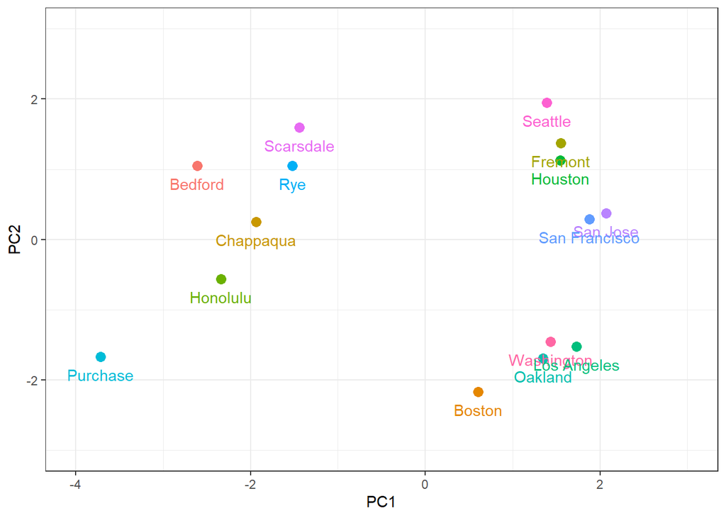

```r
selected_info =
  all_info %>%
  janitor::clean_names() %>%
  select(overall_rating, housing, education, cost_of_living, unemployment, commute, lifestyle)
rownames(selected_info) = c("Chappaqua", "Bedford","Rye","Purchase","Scarsdale","Fremont", "Oakland", "San Jose", "Honolulu", "San Francisco", "Boston", "Washington","Los Angeles", "Houston","Seattle")

pca_res <- prcomp(selected_info, scale. = TRUE)




df <- as.data.frame(pca_res$x)
df$city <- rownames(df)

ggplot(df, aes(PC1, PC2, color = city)) +
  geom_point(size = 3) +
  geom_text(aes(label = city) , vjust = 2) +
  lims(x = c(-4, 3), y = c(-3, 3)) +
  theme_bw() +
  theme(legend.position = "none")
```

Honolulu has a rating that is close to the four target areas, so I include the city in the price time series plot. Seattle is also included for a reference as it has a high house price per square feet and it is a well developed city.

### House price time series

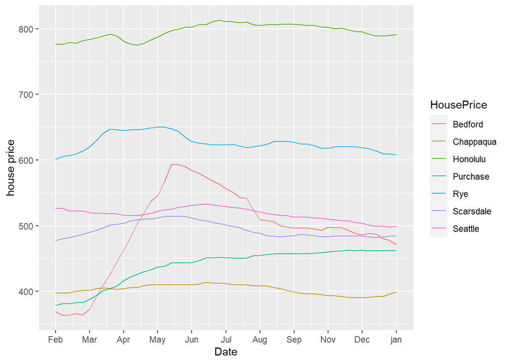

```r
time = colnames(house_price)[3:53]
df1 = t(house_price[,3:53])
data_df1 = melt(df1)
data_df1_named =
  data_df1 %>%
  mutate(Var2 = ifelse(Var2==1,"Chappaqua",ifelse(Var2==2, "Bedford", ifelse(Var2==3, "Rye", ifelse(Var2==4, "Purchase",ifelse(Var2==5,"Scarsdale",ifelse(Var2==6,"Honolulu","Seattle")))))),
         ind = rep(1:length(time),7),
         HousePrice = Var2)
ggplot(data_df1_named, aes(x=ind, y=value, color = HousePrice))+
  geom_line()+
  labs(
    y="house price",
    x="Date"
  )+
  scale_x_continuous(
    breaks = seq(1,length(time),5),
    labels = c("Feb","Mar","Apr","May","Jun","Jul","Aug","Sep","Nov","Dec","jan"),
    limits = c(1,length(time)))
```

```r
data_df1_named %>% group_by(Var2) %>% summarize(mean_price = mean(value))
```

```
## # A tibble: 7 × 2
##   Var2      mean_price
##   <chr>          <dbl>
## 1 Bedford         494.
## 2 Chappaqua       403.
## 3 Honolulu        796.
## 4 Purchase        439.
## 5 Rye             626.
## 6 Scarsdale       494.
## 7 Seattle         518.
```

### Number of house

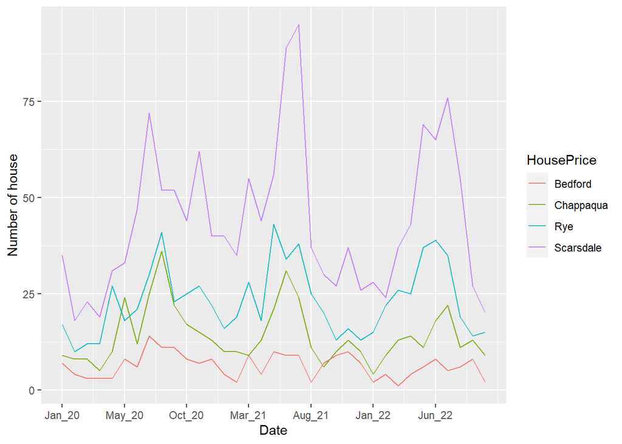

```r
time2 = colnames(num_sold)[3:37]
num_sold_num = num_sold %>% filter(City_name!="Purchase") %>% filter(City_name!="Seattle") %>% filter(City_name!="Honolulu")
df2 = t(num_sold_num[,3:37])
data_df2 = melt(df2)
data_df2_named =
  data_df2 %>%
  mutate(Var2 = ifelse(Var2==1,"Chappaqua",ifelse(Var2==2, "Bedford", ifelse(Var2==3, "Rye", "Scarsdale"))),
         ind = rep(1:length(time2),4),
         HousePrice = Var2)
ggplot(data_df2_named, aes(x=ind, y=value, color = HousePrice))+
  geom_line()+
  labs(
    y="Number of house",
    x="Date"
  )+
  scale_x_continuous(
    breaks = seq(1,length(time2),5),
    labels = c("Jan_20","May_20","Oct_20","Mar_21","Aug_21","Jan_22","Jun_22"),
    limits = c(1,length(time2)))
```

```r
data_df2_named %>% group_by(Var2) %>% summarize(mean_number = mean(value))
```

```
## # A tibble: 4 × 2
##   Var2      mean_number
##   <chr>           <dbl>
## 1 Bedford          6.31
## 2 Chappaqua       14.2
## 3 Rye             23.3
## 4 Scarsdale       44.1
```

Purchase data is not available online. Rye is the city that has the highest number of house available among three target cities.

### Medium day on the market

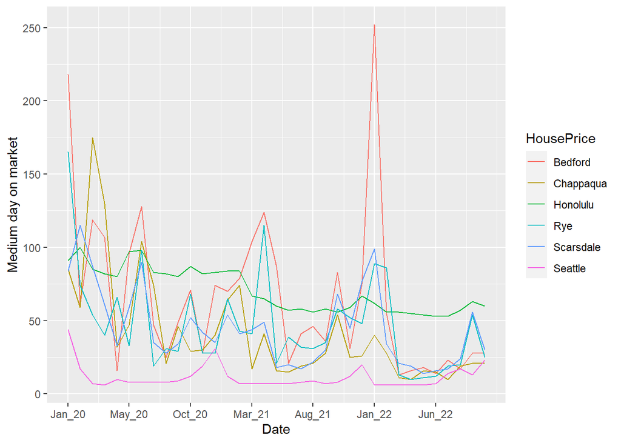

```r
time3 = colnames(medium_time)[3:37]
medium_time_num = medium_time %>% filter(City_name!="Purchase")
df3 = t(medium_time_num[,3:37])
data_df3 = melt(df3)
data_df3_named =
  data_df3 %>%
  mutate(Var2 = ifelse(Var2==1,"Chappaqua",ifelse(Var2==2, "Bedford", ifelse(Var2==3, "Rye",ifelse(Var2==4,"Scarsdale",ifelse(Var2==5,"Honolulu","Seattle"))))),
         ind = rep(1:length(time3),6),
         HousePrice = Var2)
ggplot(data_df3_named, aes(x=ind, y=value, color = HousePrice))+
  geom_line()+
  labs(
    y="Medium day on market",
    x="Date"
  )+
  scale_x_continuous(
    breaks = seq(1,length(time2),5),
    labels = c("Jan_20","May_20","Oct_20","Mar_21","Aug_21","Jan_22","Jun_22"),
    limits = c(1,length(time2)))
```

```r
data_df3_named %>% group_by(Var2) %>% summarize(mean_day = mean(value))
```

```
## # A tibble: 6 × 2
##   Var2      mean_day
##   <chr>        <dbl>
## 1 Bedford       65.7
## 2 Chappaqua     41.8
## 3 Honolulu      70.6
## 4 Rye           47.2
## 5 Scarsdale     44.9
## 6 Seattle       11.5
```

Bedford has a relatively high number of days on the market before sold.